# Practical 3

# Assessing Missing Data

Now we know that there is a substantial amount of missing data, it is time to assess how severe the missingness problem is. One way to do this is by asking for the missing data pattern, using the function `md.pattern()` from `mice`.

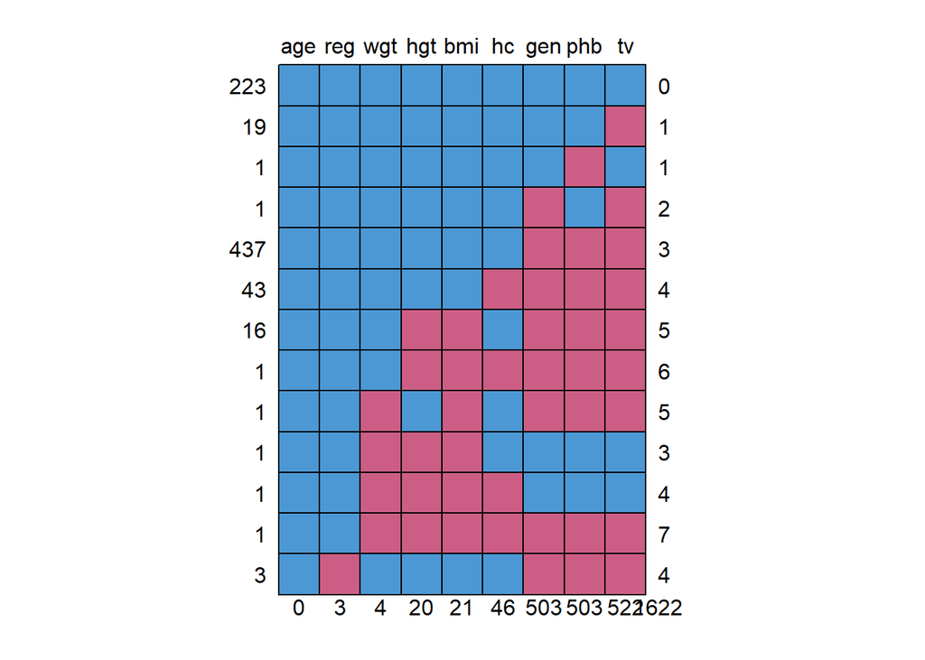

```
##     age reg wgt hgt bmi hc gen phb  tv
## 223   1   1   1   1   1  1   1   1   1    0
## 19    1   1   1   1   1  1   1   1   0    1
## 1     1   1   1   1   1  1   1   0   1    1
## 1     1   1   1   1   1  1   0   1   0    2
## 437   1   1   1   1   1  1   0   0   0    3
## 43    1   1   1   1   1  0   0   0   0    4
## 16    1   1   1   0   0  1   0   0   0    5
## 1     1   1   1   0   0  0   0   0   0    6
## 1     1   1   0   1   0  1   0   0   0    5
## 1     1   1   0   0   0  1   1   1   1    3
## 1     1   1   0   0   0  0   1   1   1    4
## 1     1   1   0   0   0  0   0   0   0    7
## 3     1   0   1   1   1  1   0   0   0    4
##       0   3   4  20  21 46 503 503 522 1622
```

```r
md.pattern(boys)
```

**3: Create a missingness indicator for the variables `gen`, `phb` and `tv`.**

```r
missing_boys <- boys %>%
  mutate(gen_missing = is.na(gen),
         phb_missing = is.na(phb),
         tv_missing = is.na(tv))
```

**4:Assess whether missingness in the variables `gen`, `phb` and `tv` is related to someones age.**

```r
missing_boys %>%
  group_by(gen_missing) %>%
  summarise("mis_age_gen" = mean(age))
```

```
## # A tibble: 2 x 2
##   gen_missing mis_age_gen
##   <lgl>             <dbl>
## 1 FALSE             14.0
## 2 TRUE               6.79
```

```r
missing_boys %>%
  group_by(phb_missing) %>%
  summarise("mis_phb_gen" = mean(age))
```

```
## # A tibble: 2 x 2
##   phb_missing mis_phb_gen
##   <lgl>             <dbl>
## 1 FALSE             14.0
## 2 TRUE               6.79
```

```r
missing_boys %>%
  group_by(tv_missing) %>%
  summarise("mis_tv_gen" = mean(age))
```

```
## # A tibble: 2 x 2
##   tv_missing mis_tv_gen
##   <lgl>           <dbl>
## 1 FALSE           14.1
## 2 TRUE             7.02
```

From this, we can see that those with a lower age tend to have more missing data than those with a higher age.

**5: Create a histogram for the variable `age`, faceted by whether or not someone has a missing value on `gen`.**

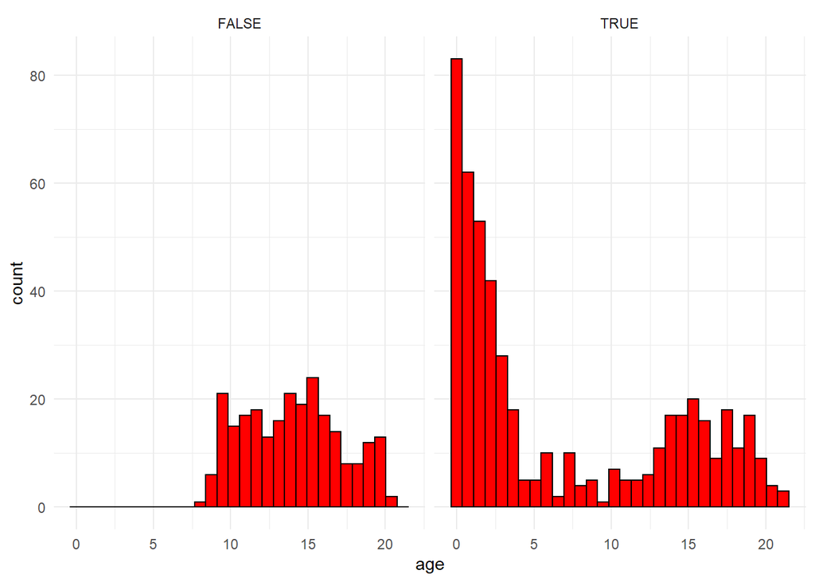

```r
missing_boys %>%
  ggplot(aes(x = age)) +
  geom_histogram(color = "black", fill = "red") +
  facet_wrap( ~ gen_missing) +
  theme_minimal()
```

These histograms show us that missing values for the gen variable very frequently happen between the ages of 0 and 5.

**6: Create a scatterplot with `age` on the x-axis and `bmi` on the y-axis, using the function `geom_point()`.**

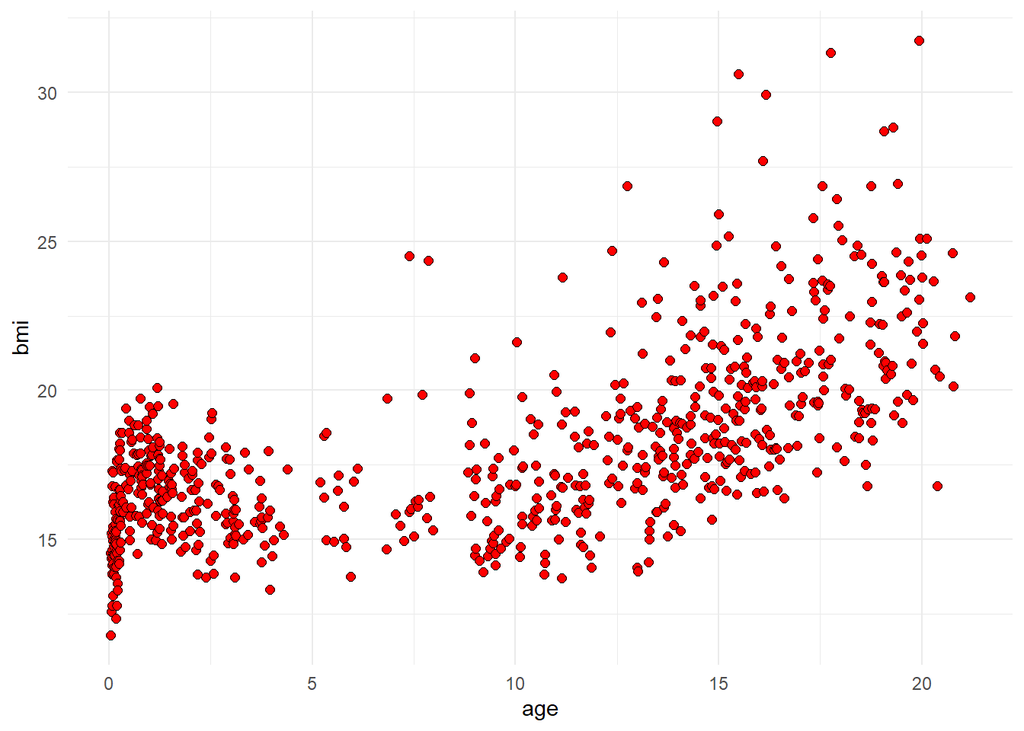

```r
missing_boys %>%
  ggplot(aes(x = age, y = bmi)) +
  geom_point(shape = 21, fill = "red", color = "black", size = 2) +
  theme_minimal()
```

From this scatterplot, we can see that, as `age` increases, `bmi` also increases. However, there is a cluster around 0. This makes sense though, as if you do not exist, you would not have a BMI.

**7: Add a colour aesthetic to the previous plot using the missingness indicator of the variable `gen`.**

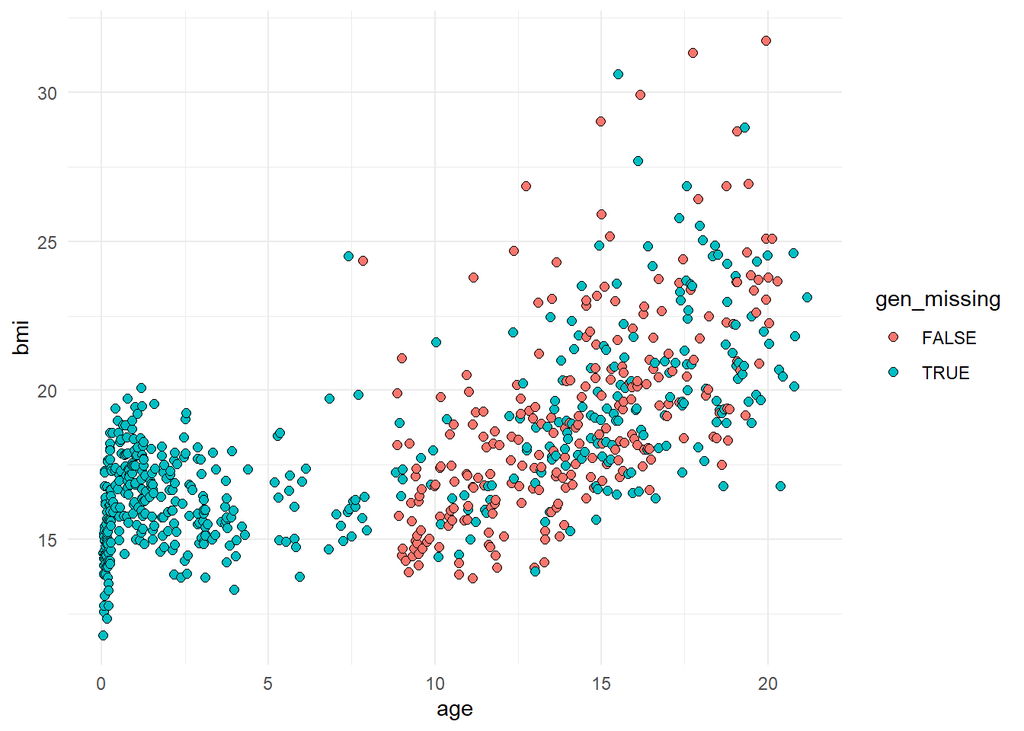

```r
missing_boys %>%
  ggplot(aes(x = age, y = bmi)) +
  geom_point(aes(fill = gen_missing), shape = 21, color = "black", size = 2) +
  theme_minimal()
```

From this scatterplot, we can see that we have a substantial amount of missing values for `gen`, especially between the ages of 0 and about 7. We see this before in the faceted histogram.

# Visualizing the `boys` data

**8: Visualize the relationship between `reg` (region) and `age` using a boxplot.**

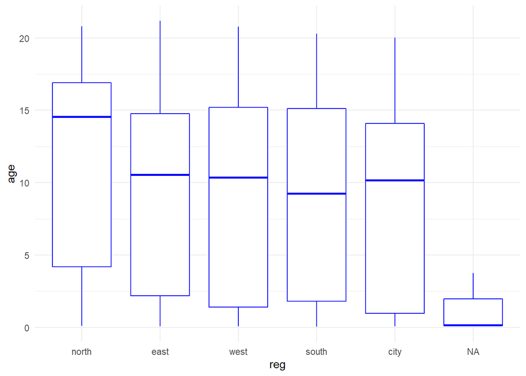

```r
boys %>%
  ggplot(aes(x = reg, y = age))+
  geom_boxplot(color = "blue")+
  theme_minimal()
```

**9: Create a density plot of `age`, splitting the densities by `gen` using the fill aesthetic.**

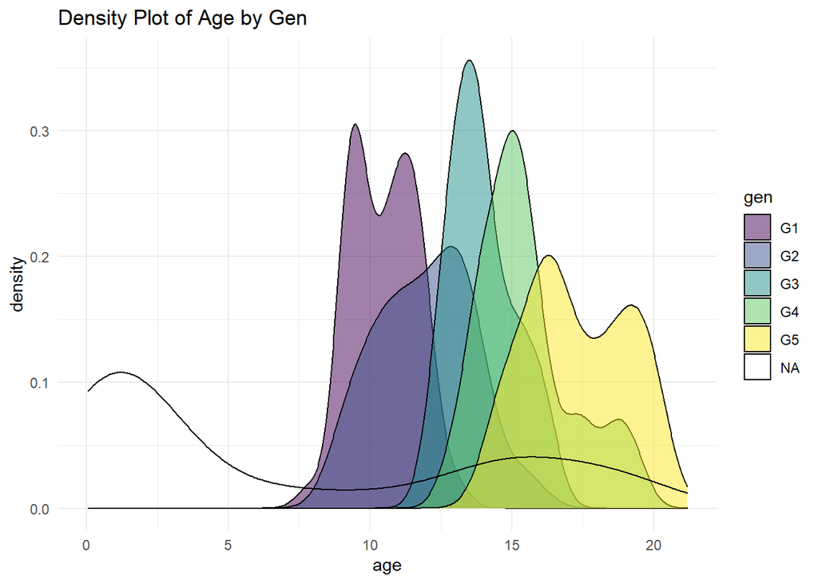

```r
boys %>%
  ggplot(aes(x = age)) +
  geom_density(aes(fill = gen), alpha = .5) +
  theme_minimal() +
  labs(title = "Density Plot of Age by Gen")
```

**10: Create a diverging bar chart for `hgt` in the `boys` data set, that displays for every age year that year’s mean height in deviations from the overall average hgt.**

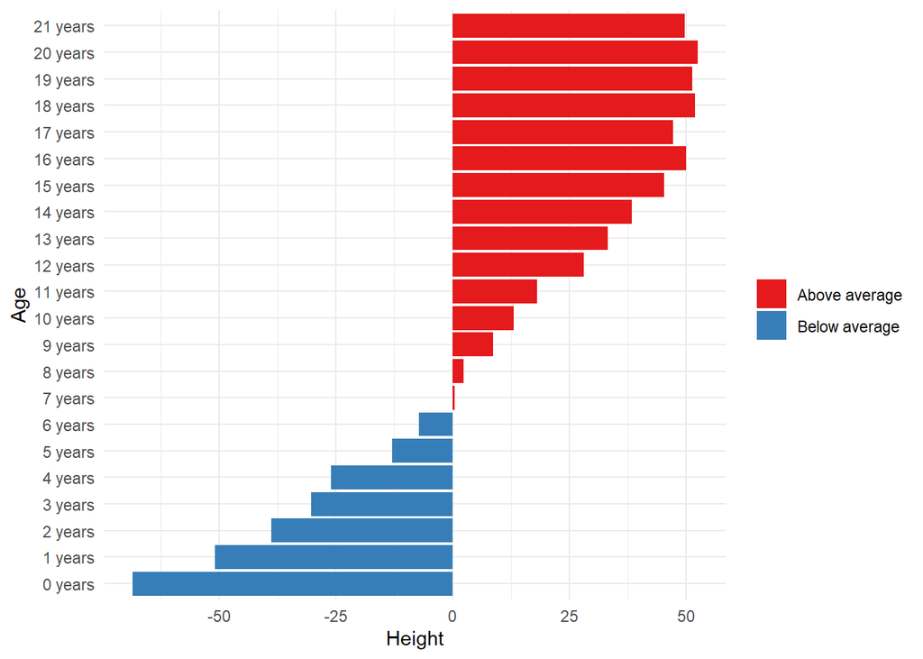

```r
boys %>%
  mutate(Age = cut(age, 0:22, labels = paste0(0:21, " years")),
         Height = hgt - mean(hgt, na.rm = TRUE)) %>% #creating two new variables with Age as a category and centered height variable
  group_by(Age) %>% #grouping by the Age category variable we created in the first mutuate
  summarize(Height = mean(Height, na.rm = TRUE)) %>% #getting the mean of the centered height variable grouped by age
  mutate(color = ifelse(Height > 0, "Above average", "Below average")) %>% #creating a dichotomous variable for above and below average heights
  ggplot(aes(x = Height, y = Age, fill = color)) + #creating the base ggplot code
  geom_bar(stat = "identity") + #setting the geom as a bar chart
  scale_fill_brewer(palette = "Set1") + #setting the color scheme
  theme_minimal() + #setting the theme to minimal
  theme(legend.title = element_blank()) #removing the legend title
```

# Regression Visualization

**11: Load the data `elastic1` and `elastic2` and bind the data frames together using the function `bind_rows()` and add a grouping variable indicating whether an observation comes from `elastic1` or from `elastic2`.**

```r
elastic3 <- bind_rows("elastic1" = elastic1,
                      "elastic2" = elastic2,
                      .id = "set")
```

**12: 12. Create a scatterplot mapping `stretch` on the x-axis and `distance` on the y-axis, and map the just created group indicator as the color aesthetic.**

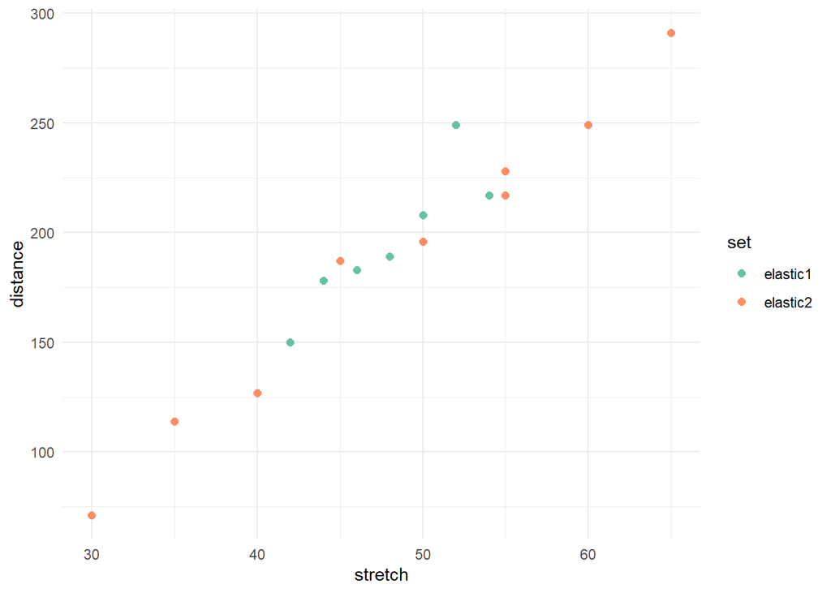

```r
elastic3 %>%
  ggplot(aes(x = stretch, y = distance)) +
  geom_point(aes(color = set), size = 2) +
  theme_minimal() +
  scale_color_brewer(palette = "Set2")
```

**13: Recreate the previous plot, but now assess whether the results of the two data sets appear consistent by adding a linear regression line.**

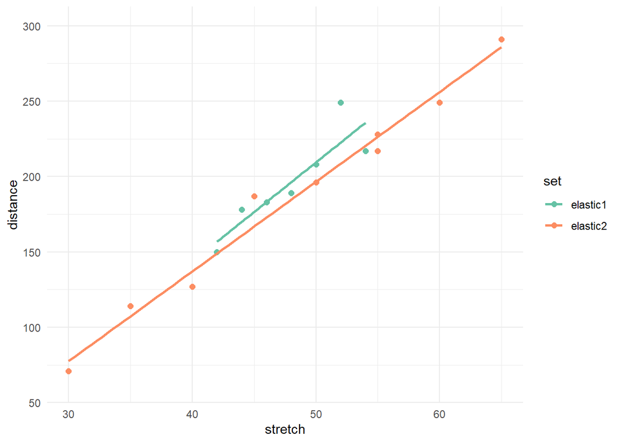

```r
elastic3 %>%
  ggplot(aes(x = stretch, y = distance)) +
  geom_point(aes(color = set), size = 2) +
  geom_smooth(method = "lm", aes(color = set), fill = NA) +
  theme_minimal() +
  scale_color_brewer(palette = "Set2")
```

**14: For each of the data sets `elastic1` and `elastic2`, fit a regression model with `y = distance` on `x = stretch` using `lm(y ~ x, data)`.**

```r
#model 1 for the elastic1 dataset
mod1 <- elastic1 %$%
  lm(distance ~ stretch)
summary(mod1)
```

```
##
## Call:
## lm(formula = distance ~ stretch)
##
## Residuals:
##        1        2        3        4        5        6        7
##  -0.1429 -18.7143  -7.2857  -1.4286   8.0000  -6.8571  26.4286
##
## Coefficients:
##             Estimate Std. Error t value Pr(>|t|)
## (Intercept) -119.143     70.943  -1.679  0.15391
## stretch        6.571      1.473   4.462  0.00663 **
## ---
## Signif. codes:  0 '***' 0.001 '**' 0.01 '*' 0.05 '.' 0.1 ' ' 1
##
## Residual standard error: 15.59 on 5 degrees of freedom
## Multiple R-squared:  0.7992, Adjusted R-squared:  0.7591
## F-statistic: 19.91 on 1 and 5 DF,  p-value: 0.006631
```

According to this output, `stretch` is a significant predictor of `distance`. For every 1 unit increase in `stretch`, `distance` increases by 6.57 units. In this model, the intercept is not significant.

```r
#model 2 for the elastic2 dataset
mod2 <- elastic2 %$%
  lm(distance ~ stretch)
summary(mod2)
```

```
##
## Call:
## lm(formula = distance ~ stretch)
##
## Residuals:
##      Min       1Q   Median       3Q      Max
## -10.0833  -7.0833  -0.5833   5.1667  20.1667
##
## Coefficients:
##              Estimate Std. Error t value Pr(>|t|)
## (Intercept) -100.9167    15.6102  -6.465 0.000345 ***
## stretch        5.9500     0.3148  18.899 2.89e-07 ***
## ---
## Signif. codes:  0 '***' 0.001 '**' 0.01 '*' 0.05 '.' 0.1 ' ' 1
##
## Residual standard error: 10.44 on 7 degrees of freedom
## Multiple R-squared:  0.9808, Adjusted R-squared:  0.978
## F-statistic: 357.2 on 1 and 7 DF,  p-value: 2.888e-07
```

According to this output, `stretch` is a significant predictor of `distance`. For every 1 unit increase in `stretch`, `distance` increases by 5.95 units. In this model, the intercept is significant.

**15: For both of the previously created fitted models, determine the fitted values and the standard errors of the fitted values, and the proportion explained variance R2**

```r
mod1 %>%
  predict(se.fit = T)
```

```
## $fit
##        1        2        3        4        5        6        7
## 183.1429 235.7143 196.2857 209.4286 170.0000 156.8571 222.5714
##
## $se.fit
## [1]  6.586938 10.621119  5.891537  6.586938  8.331891 10.621119  8.331891
##
## $df
## [1] 5
##
## $residual.scale
## [1] 15.58754
```

```r
mod2 %>%
  predict(se.fit = T)
```

```
## $fit
##         1         2         3         4         5         6         7         8
##  77.58333 196.58333 137.08333 166.83333 256.08333 226.33333 107.33333 226.33333
##         9
## 285.83333
##
## $se.fit
## [1] 6.740293 3.520003 4.358744 3.635444 5.060323 4.064550 5.453165 4.064550
## [9] 6.296773
##
## $df
## [1] 7
##
## $residual.scale
## [1] 10.44202
```

Now, we will look at the R2 values for each of the models.

```r
mod1 %>%
  summary() %$%
  r.squared
```

```
## [1] 0.7992446
```

The R squared value is 0.80. This means that 80% of the variation in the dependent variable (Y) is explained by the predictor(s) (X).

```r
mod2 %>%
  summary() %$%
  r.squared
```

```
## [1] 0.9807775
```

The R squared value is 0.98. This means that 98% of the variation in the dependent variable (Y) is explained by the predictor(s) (X).

From examining the standard error of the residuals and the R2 values for each model, we can see that model 2 has lower standard errors and a higher R2. This is because elastic2 has a range of values and lacks an outlier.

**16: Study the residual versus leverage plots for both models.**

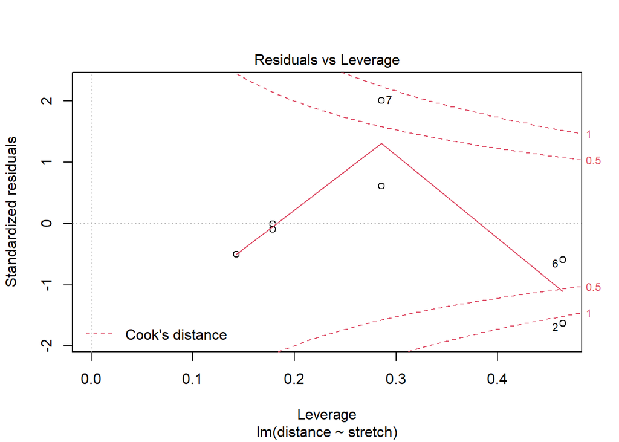

```r
#residual plot for mod1 (elastic1)
mod1 %>%
  plot(which = 5)
```

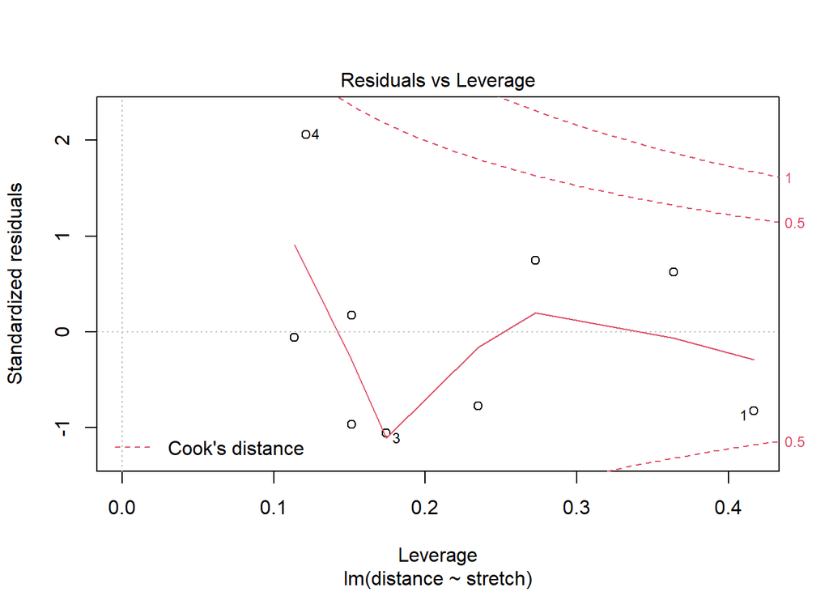

```r
#residual plot for mod2 (elastic2)
mod2 %>%
  plot(which = 5)
```

For elastic1, case 2 is shown to have the highest influence on estimation. But, if we look at the residuals, we can see that case 7 has the highest residual.

```r
mod1$residuals
```

```
##           1           2           3           4           5           6
##  -0.1428571 -18.7142857  -7.2857143  -1.4285714   8.0000000  -6.8571429
##           7
##  26.4285714
```

**17: Use the `elastic2` variable `stretch` to obtain predictions on the model fitted on `elastic1`.**

```r
pred <- predict(object = mod1, newdata = elastic2)
```

I believe this makes it so that we are predicting `elastic1` `distance` by `elastic2` `stretch`.

**18: Now make a scatterplot to investigate similarity between the predicted values and the observed values for `elastic2`.**

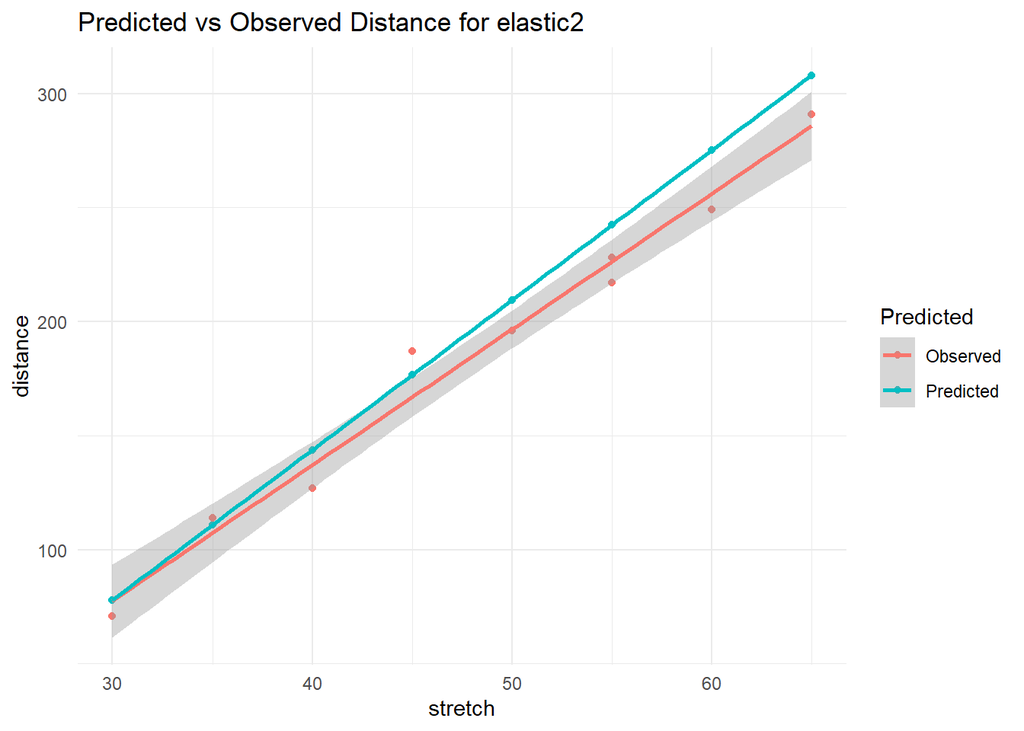

```r
pred_dat <-
  data.frame(distance = pred, #predicted distance
             stretch  = elastic2$stretch) %>% #keeping the stretch variable (predictor) as is
  bind_rows("Predicted" = ., #now, we are going to bind the rows together, as we did before in a previous example. In this, we are bidning the rows of the predicted data frame and the original elastic2 data set.
            "Observed"  = elastic2,
            .id = "Predicted")

pred_dat %>%
  ggplot(aes(x = stretch, y = distance, color = Predicted)) +
  geom_point() +
  geom_smooth(method = "lm") +
  theme_minimal() +
  labs(title = "Predicted vs Observed Distance for elastic2")
```

Trying a different way of doing this, which is how I originally coded it.

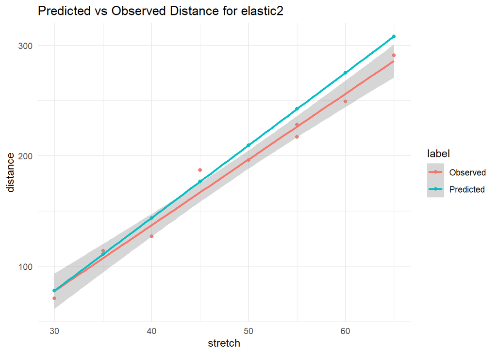

```r
pred_df <-
  data.frame("distance" = c(pred, elastic2$distance),
             "stretch" = rep(elastic2$stretch, 2),
             "label" = c(rep("Predicted", 9), rep("Observed", 9)))

pred_df %>%
  ggplot(aes(x = stretch, y = distance, color = label)) +
  geom_point() +
  geom_smooth(method = "lm") +
  theme_minimal() +
  labs(title = "Predicted vs Observed Distance for elastic2")
```

Ultimately, the results are the same.